# Mixed-Effects Models

Misc. Hierarchical Examples-Crossed

Background: https://www.youtube.com/watch?v=-4K-kKXNths

Up to this point our analyses have dealt mainly with just one or two explanatory variables. For the most part these have been experimental treatments that have been deliberately applied in a particular way because we are interested in the treatment effects. These types of explanatory variables are often referred to as **fixed effects** (we fix the levels of the experimental treatments).

However, there is often hierarchical structure in our data, such as with blocked designs. Sometimes we deliberately choose to have blocked designs, but in other cases they are forced upon us by circumstances. Sometimes we might know how the blocks differ, but this knowledge is never complete and we often have little idea how or why one block differs from another. We just know that blocks will differ due to the ubiquitous variability of the natural world.

These blocking terms and related variables go by a variety of names including nuisance variables and **random effects**. Statistical models that include both fixed and random effects are called mixed-effects models, or sometimes just **mixed models**.

**Fixed vs. Random Effects** Dingemanse and Dochtermann (2013; J. Animal Ecology 82:39-54)

Mixed-effect models incorporate two types of parameters:

1. The effects that predictor variables – which can be continuous (covariates) or categorical (factors) – have on the mean of response variables. Such effects are called **‘fixed’** whenever specific effects are estimated at their observed levels (e.g. differences in means between four specific years of study).

A “fixed variable” is one that is assumed to be measured without error (e.g. sex).

It is also assumed that the values of a fixed variable in one study are the same as the values of the fixed variable in another study (e.g. burned, unburned; control, experimental).

2. Effects on response variables generated by variation within and among levels of a predictor variable (factor). Effects of such predictor variables are called **‘random’** whenever variance is estimated among **observed levels sampled from a population of levels**.

You can think of the values of random variables as representing a random sample of all possible values or instances of that variable (age, IQ, body mass, blood pressure), including repeated sampling of replicates (individuals, plots, etc) across time.

We expect to generalize the results obtained with a random variable to all other possible instances of that value. In traditional ANOVA and regression analysis we assume the predictor variables are fixed, but mixed-effects models allow us to relax that assumption (and calculations are also relaxed).

**Part One**  
**Repeated Measures Example**  
One of the main assumptions of a traditional OLS regression model is that collected samples are independent. What about a design where you measure the same replicates more than once, like a before-after comparison? Observations are obviously not independent.

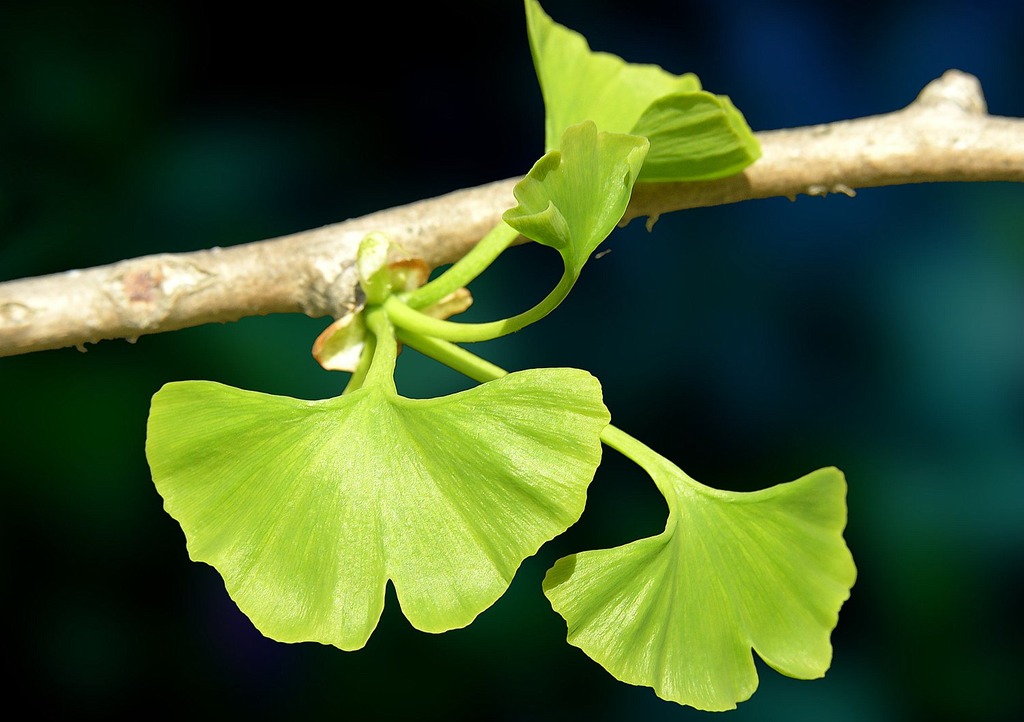

```r
treat  = rep(c('treat', 'control'), e=5)
pre = c(31,12,53,24,15,36,17,38,20,10)
post = c(41,50,80,60,50,20,19,38,50,12)

dfwide <- data.frame(id=factor(1:10), treat, pre, post) #wide data frame
dflong <- tidyr::gather(dfwide, key=time, value=score, pre:post) %>% arrange(id) #long dataframe
dflong$time = factor(dflong$time, levels = c("pre", "post")) #reorder factor to be pre then post
```

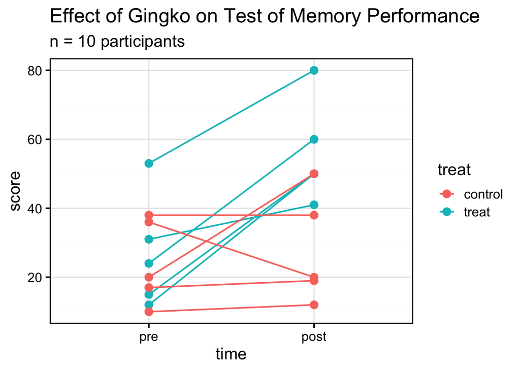

```r
ggplot(dflong, aes(x=time, y=score, color=treat)) +
  geom_line(aes(group=id)) +
  geom_point(size=3) +
  ggtitle(label = "Effect of Gingko on Test of Memory Performance",
          subtitle = "n = 10 participants") +
  theme_cmg()
```

```r
#fit an OLS linear model in the way we are accustomed to.
olsModel <- lm(score ~ treat + time + treat*time, data=dflong)
anova(olsModel)
```

```
## Analysis of Variance Table
##
## Response: score
##            Df Sum Sq Mean Sq F value  Pr(>F)
## treat       1 1216.8 1216.80  5.4928 0.03234 *
## time        1 1344.8 1344.80  6.0706 0.02546 *
## treat:time  1  819.2  819.20  3.6980 0.07246 .
## Residuals  16 3544.4  221.52
## ---
## Signif. codes:  0 '***' 0.001 '**' 0.01 '*' 0.05 '.' 0.1 ' ' 1
```

**THIS IS WHAT NOT TO DO! This model has ONLY Fixed Effects.**  
This model is fit using only fixed effects, producing WAY too many residual df. Does not account for the hierarchical nature of the experiment; individuals are tested multiple times in each treatment. Number of individuals was only n=10, so this model has artificially inflated sample size. This analysis can’t possibly be correct.

Need to fit a model that accounts for the repeated measurement of individuals (each person twice).

We will use a new package called `lme4` and the function `lmer` (linear mixed effects regression).

```r
#note new syntax for model specification
lmeModel <- lmer(score ~ treat*time + (1|id), data=dflong)
anova(lmeModel)
```

```
## Type III Analysis of Variance Table with Satterthwaite's method
##             Sum Sq Mean Sq NumDF DenDF F value   Pr(>F)
## treat       363.34  363.34     1     8  3.5665 0.095644 .
## time       1344.80 1344.80     1     8 13.2005 0.006654 **
## treat:time  819.20  819.20     1     8  8.0412 0.021957 *
## ---
## Signif. codes:  0 '***' 0.001 '**' 0.01 '*' 0.05 '.' 0.1 ' ' 1
```

```r
#notice that the default for mixed models has slightly different output than normal OLS model.
```

However, now we are using a tool that can handle additional time points, continuous covariates with possibly nonlinear relationships, different types of outcome variables, other correlational structures among the observations, etc. In fact, if one looks at the help file for `aov`, one will note that it suggests using `lme` for unbalanced designs and other situations.

*The slot machine example “Machine” is an example of a mixed-model with unbalanced sample sizes.*

**Machine** Unbalanced repeated measures ANOVA; Data are ratings for three slot machine types, each used by six different players.

We can model this as a mixed-model ANOVA since we have repeated measurements from each individual; often playing more than once on each machine type (treatment). Data can be considered hierarchical.  
(Example from JMP: Machine.jmp; model specification slightly different than example).

[figure not shown]

```r
data <- read.csv("../data/Machine2.csv")
data$person <- as.factor(data$person) #make person ID a factor
```

Unbalanced data: Not every individual equally represented across treatments

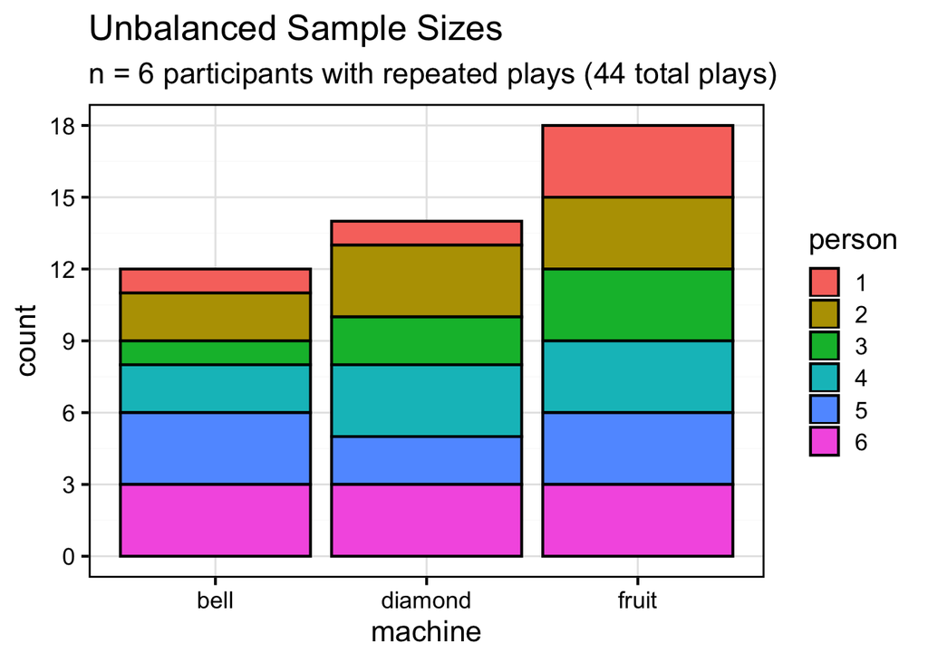

```r
ggplot(data, aes(machine, fill=person)) +
  geom_bar(color="black") +
  scale_y_continuous(breaks=seq(0,18,3)) +
  ggtitle(label = "Unbalanced Sample Sizes",
          subtitle = "n = 6 participants with repeated plays (44 total plays)") +
  theme_cmg()
```

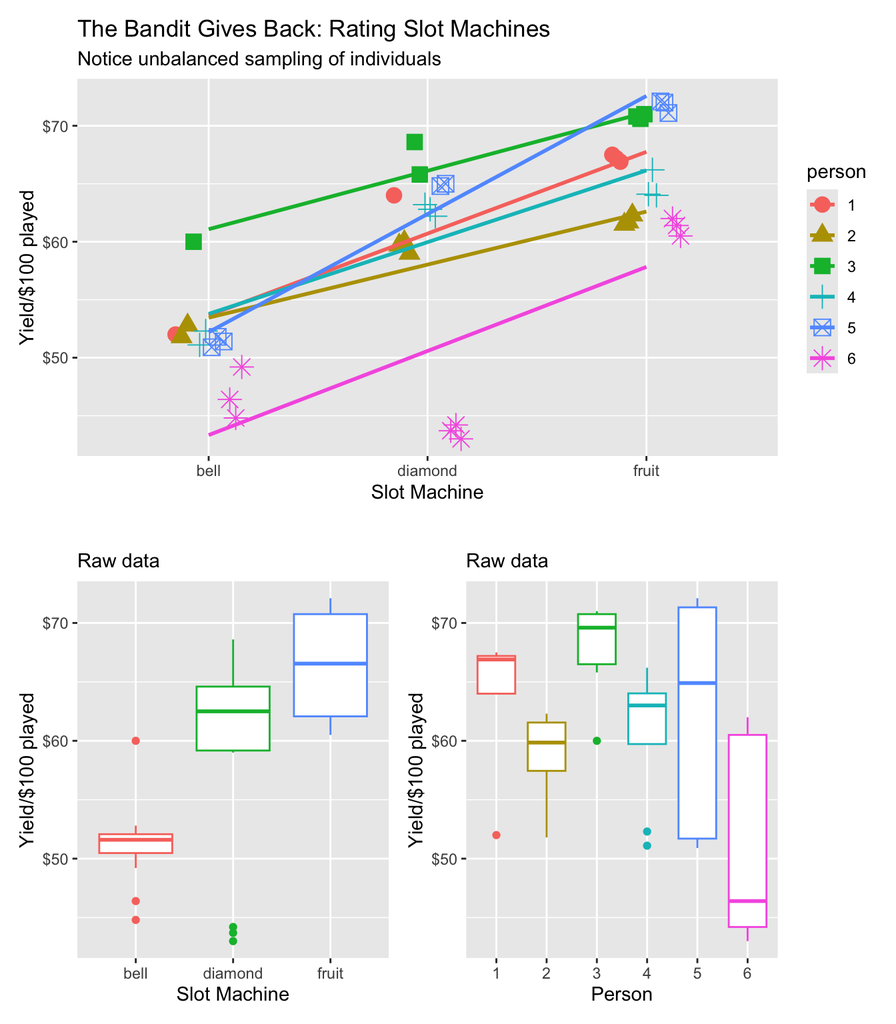

```r
p1a<- ggplot(data, aes(x=machine, y=rating, group=person, color=person, shape=person)) +
  geom_point(size=4, position = position_dodge2(width=.33, preserve = "total")) +
  scale_y_continuous(labels=scales::dollar_format()) +
  #geom_line() +
  geom_smooth(method = "lm", se = FALSE) +
  labs(title="The Bandit Gives Back: Rating Slot Machines",
       subtitle = "Notice unbalanced sampling of individuals",
       x= "Slot Machine",
       y = "Yield/$100 played")

#box plot of raw data by machine; does not adjust for repeated measures of individuals
p1b <- ggplot(data, aes(x=machine, y=rating, color=machine)) +
  geom_boxplot() +
  scale_y_continuous(labels=scales::dollar_format()) +
  theme(legend.position="none") +
  labs(title="",
       subtitle = "Raw data",
       x= "Slot Machine",
       y = "Yield/$100 played")

#box plot of raw data by person
p1c <- ggplot(data, aes(x=person, y=rating, color=person)) +
  geom_boxplot() +
  scale_y_continuous(labels=scales::dollar_format()) +
  theme(legend.position="none") +
  labs(title="",
       subtitle = "Raw data",
       x= "Person",
       y = "Yield/$100 played")

  p1a / (p1b + p1c) #uses library(patchwork) for plot organization)
```

https://www.americancasinoguidebook.com/slot-machine-payback-statistics.html#Nevada

```r
machines_means <- data %>%
  group_by(machine) %>%
  summarise(mean_rating=mean(rating),
            se_rating=sd(rating)/sqrt(n()))
machines_means
```

```
## # A tibble: 3 × 3
##   machine mean_rating se_rating
##   <chr>         <dbl>     <dbl>
## 1 bell           51.2     1.07
## 2 diamond        59       2.33
## 3 fruit          66.3     0.989
```

```r
mixed_machine <- lmer(rating ~ machine * person + (1|person), data = data)

anova(mixed_machine) #notice it doesn't report whether whole model is significant or model fit, but we likely don't care anyway.
```

```
## Type III Analysis of Variance Table with Satterthwaite's method
##                 Sum Sq Mean Sq NumDF DenDF F value    Pr(>F)
## machine        1238.20  619.10     2    26 709.517 < 2.2e-16 ***
## person          222.30   44.46     5    26  50.953 1.302e-12 ***
## machine:person  404.32   40.43    10    26  46.336 5.226e-14 ***
## ---
## Signif. codes:  0 '***' 0.001 '**' 0.01 '*' 0.05 '.' 0.1 ' ' 1
```

```r
summary(mixed_machine)
```

```
## Linear mixed model fit by REML. t-tests use Satterthwaite's method [
## lmerModLmerTest]
## Formula: rating ~ machine * person + (1 | person)
##    Data: data
##
## REML criterion at convergence: 85.1
##
## Scaled residuals:
##     Min      1Q  Median      3Q     Max
## -2.1411 -0.5085  0.0000  0.4104  2.5693
##
## Random effects:
##  Groups   Name        Variance Std.Dev.
##  person   (Intercept) 0.4145   0.6438
##  Residual             0.8726   0.9341
## Number of obs: 44, groups:  person, 6
##
## Fixed effects:
##                        Estimate Std. Error       df t value Pr(>|t|)
## (Intercept)             52.0000     1.1345  26.0000  45.836  < 2e-16 ***
## machinediamond          12.0000     1.3210  26.0000   9.084 1.51e-09 ***
## machinefruit            15.2000     1.0786  26.0000  14.092 1.10e-13 ***
## person2                  0.3000     1.4621  26.0000   0.205 0.839027
## person3                  8.0000     1.6044  26.0000   4.986 3.48e-05 ***
## person4                 -0.3000     1.4621  26.0000  -0.205 0.839027
## person5                 -0.6333     1.4115  26.0000  -0.449 0.657369
## person6                 -5.2000     1.4115  26.0000  -3.684 0.001060 **
## machinediamond:person2  -4.7333     1.5723  26.0000  -3.010 0.005739 **
## machinefruit:person2    -5.6667     1.3750  26.0000  -4.121 0.000341 ***
## machinediamond:person3  -4.8000     1.7476  26.0000  -2.747 0.010784 *
## machinefruit:person3    -4.4000     1.5254  26.0000  -2.884 0.007776 **
## machinediamond:person4  -0.9667     1.5723  26.0000  -0.615 0.544035
## machinefruit:person4    -2.1333     1.3750  26.0000  -1.552 0.132860
## machinediamond:person5   1.5333     1.5723  26.0000   0.975 0.338453
## machinefruit:person5     5.1667     1.3210  26.0000   3.911 0.000589 ***
## machinediamond:person6 -15.1667     1.5254  26.0000  -9.943 2.39e-10 ***
## machinefruit:person6    -0.7000     1.3210  26.0000  -0.530 0.600686
## ---
## Signif. codes:  0 '***' 0.001 '**' 0.01 '*' 0.05 '.' 0.1 ' ' 1
```

```
##
## Correlation matrix not shown by default, as p = 18 > 12.
## Use print(x, correlation=TRUE)  or
##     vcov(x)        if you need it
```

```r
#most likely you have no interest in this table, but one helpful thing is that it reports
#"Number of obs: 44, groups:  person, 6", so you know its accounted for the repeated measures
```

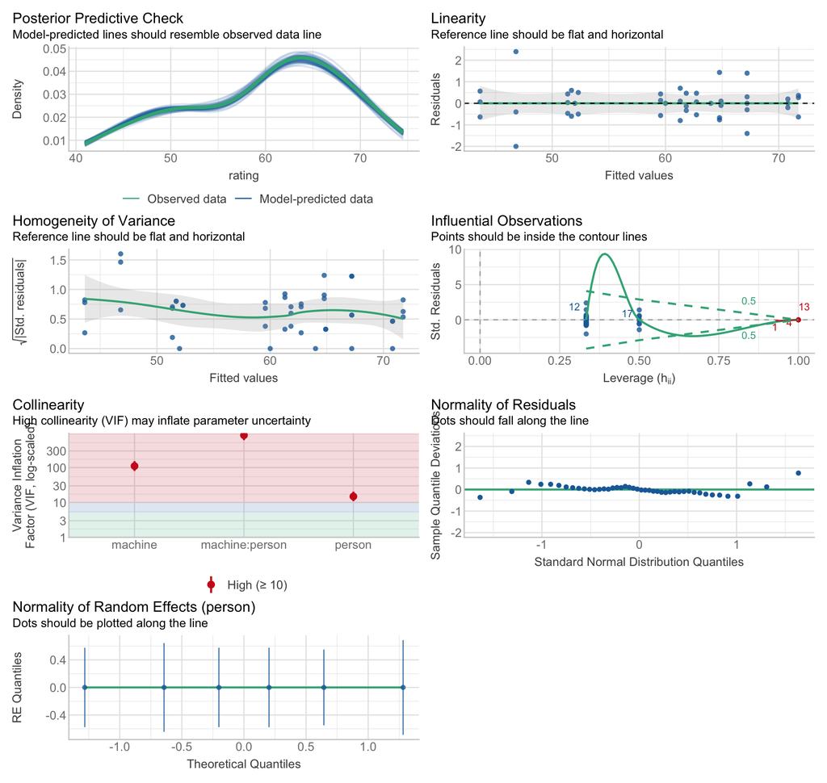

```r
performance::check_model(mixed_machine)
```

```r
#calculate model-adjusted means (e.g. estimated marginal means)
mixed_machine_emm <- emmeans(mixed_machine, "machine")
```

```
## NOTE: Results may be misleading due to involvement in interactions
```

```r
mixed_machine_emm
```

```
##  machine emmean    SE    df lower.CL upper.CL
##  bell      52.4 0.397  82.1     51.6     53.2
##  diamond   60.3 0.377  98.9     59.6     61.1
##  fruit     66.3 0.343 152.9     65.6     66.9
##
## Results are averaged over the levels of: person
## Degrees-of-freedom method: kenward-roger
## Confidence level used: 0.95
```

```r
emmeans(mixed_machine, "person")
```

```
## NOTE: Results may be misleading due to involvement in interactions
```

```
##  person emmean    SE  df lower.CL upper.CL
##  1        61.1 0.800 209     59.5     62.6
##  2        57.9 0.726 566     56.5     59.3
##  3        66.0 0.770 289     64.5     67.5
##  4        59.7 0.726 566     58.3     61.2
##  5        62.7 0.726 566     61.2     64.1
##  6        50.6 0.715 723     49.2     52.0
##
## Results are averaged over the levels of: machine
## Degrees-of-freedom method: kenward-roger
## Confidence level used: 0.95
```

```r
emmeans(mixed_machine, "machine", "person") #reverse the order of factors for alternative output
```

```
## person = 1:
##  machine emmean    SE    df lower.CL upper.CL
##  bell      52.0 1.134  56.6     49.7     54.3
##  diamond   64.0 1.134  56.6     61.7     66.3
##  fruit     67.2 0.840 152.9     65.5     68.9
##
## person = 2:
##  machine emmean    SE    df lower.CL upper.CL
##  bell      52.3 0.922  98.9     50.5     54.1
##  diamond   59.6 0.840 152.9     57.9     61.2
##  fruit     61.8 0.840 152.9     60.2     63.5
##
## person = 3:
##  machine emmean    SE    df lower.CL upper.CL
##  bell      60.0 1.134  56.6     57.7     62.3
##  diamond   67.2 0.922  98.9     65.4     69.0
##  fruit     70.8 0.840 152.9     69.1     72.5
##
## person = 4:
##  machine emmean    SE    df lower.CL upper.CL
##  bell      51.7 0.922  98.9     49.9     53.5
##  diamond   62.7 0.840 152.9     61.1     64.4
##  fruit     64.8 0.840 152.9     63.1     66.4
##
## person = 5:
##  machine emmean    SE    df lower.CL upper.CL
##  bell      51.4 0.840 152.9     49.7     53.0
##  diamond   64.9 0.922  98.9     63.1     66.7
##  fruit     71.7 0.840 152.9     70.1     73.4
##
## person = 6:
##  machine emmean    SE    df lower.CL upper.CL
##  bell      46.8 0.840 152.9     45.1     48.5
##  diamond   43.6 0.840 152.9     42.0     45.3
##  fruit     61.3 0.840 152.9     59.6     63.0
##
## Degrees-of-freedom method: kenward-roger
## Confidence level used: 0.95
```

```r
emmeans(mixed_machine, "person", "machine")
```

```
## machine = bell:
##  person emmean    SE    df lower.CL upper.CL
##  1        52.0 1.134  56.6     49.7     54.3
##  2        52.3 0.922  98.9     50.5     54.1
##  3        60.0 1.134  56.6     57.7     62.3
##  4        51.7 0.922  98.9     49.9     53.5
##  5        51.4 0.840 152.9     49.7     53.0
##  6        46.8 0.840 152.9     45.1     48.5
##
## machine = diamond:
##  person emmean    SE    df lower.CL upper.CL
##  1        64.0 1.134  56.6     61.7     66.3
##  2        59.6 0.840 152.9     57.9     61.2
##  3        67.2 0.922  98.9     65.4     69.0
##  4        62.7 0.840 152.9     61.1     64.4
##  5        64.9 0.922  98.9     63.1     66.7
##  6        43.6 0.840 152.9     42.0     45.3
##
## machine = fruit:
##  person emmean    SE    df lower.CL upper.CL
##  1        67.2 0.840 152.9     65.5     68.9
##  2        61.8 0.840 152.9     60.2     63.5
##  3        70.8 0.840 152.9     69.1     72.5
##  4        64.8 0.840 152.9     63.1     66.4
##  5        71.7 0.840 152.9     70.1     73.4
##  6        61.3 0.840 152.9     59.6     63.0
##
## Degrees-of-freedom method: kenward-roger
## Confidence level used: 0.95
```

OK, so lets look at the raw means vs. model-adjusted means (estimated marginal means)

```r
data_emm <- as.data.frame(mixed_machine_emm)
data_emm
```

```
##  machine   emmean        SE     df lower.CL upper.CL
##  bell    52.36111 0.3974268  82.12 51.57052 53.15170
##  diamond 60.33889 0.3765494  98.86 59.59172 61.08606
##  fruit   66.27222 0.3428579 152.89 65.59487 66.94957
##
## Results are averaged over the levels of: person
## Degrees-of-freedom method: kenward-roger
## Confidence level used: 0.95
```

```r
#model-adjusted means (emm) are different than raw means (see above); adjusted for the same person repeatedly evaluating the machines.
```

```r
machines_means
```

```
## # A tibble: 3 × 3
##   machine mean_rating se_rating
##   <chr>         <dbl>     <dbl>
## 1 bell           51.2     1.07
## 2 diamond        59       2.33
## 3 fruit          66.3     0.989
```

```r
#https://github.com/wilkelab/ggtext
labels <- c(
  bell = "<img src='../images/bell.jpg' width='75' /><br>Bell of Fortune", #redefine labels based on groups in df
  diamond = "<img src='../images/diamond.jpg' width='75' /><br>Diamond Blitz",
  fruit = "<img src='../images/fruit.jpg' width='75' /><br>Fruit Bonanza"
)
```

[figure not shown]

```r
##put raw means next to emmeans for visualization
p2<- ggplot(data_emm, aes(x=machine, y=emmean)) +
  geom_point(size=4) +
  geom_errorbar(aes(ymin=emmean-SE, ymax=emmean+SE), width=.2) +
  labs(title="The Bandit Gives Back: Rating Popular Slot Machines", x= NULL, y = "Machine Rating (yield/$100 played)") +
  geom_point(data=machines_means, size=4, x=machines_means$machine, y=machines_means$mean_rating, color="blue") +
  theme(axis.text.x = ggtext::element_markdown(color = "blue", size = 12)) +
  scale_x_discrete(name = NULL, labels = labels) +
  ylim(50, 67)

p2
```

Raw means are not all that different from model-adjusted means (emmeans), but does change the inference slightly.

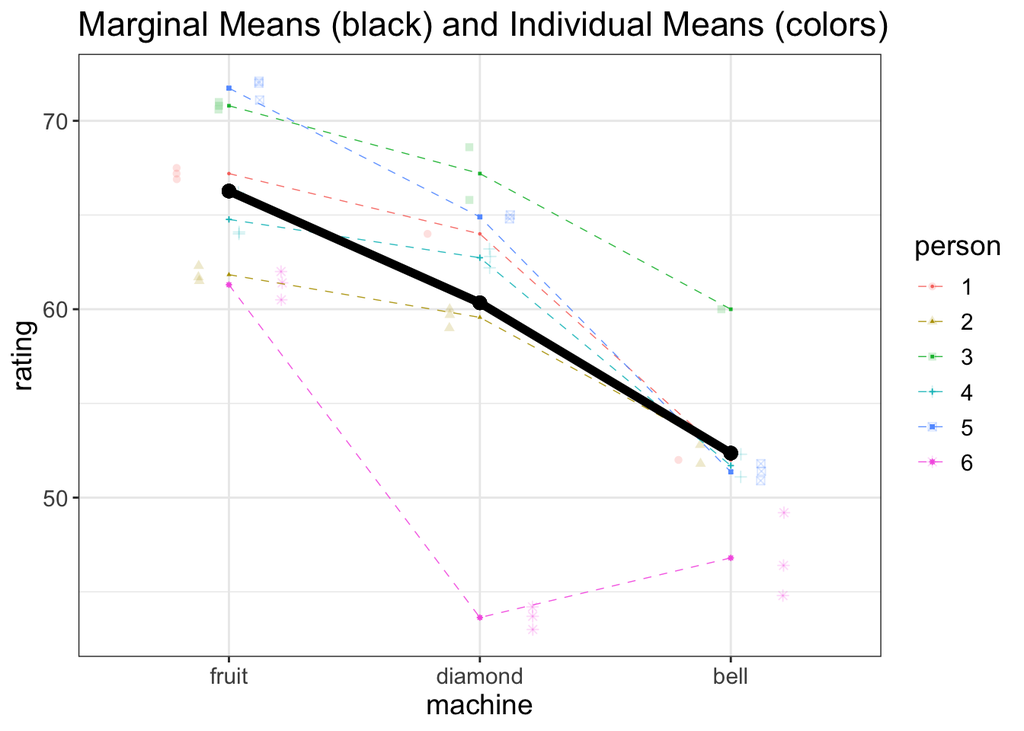

```r
fp1 <- flexplot::visualize(mixed_machine, plot="model", sample=6) +
  ggtitle("Marginal Means (black) and Individual Means (colors)")
fp1
```

```r
pairs(emmeans(mixed_machine, "machine"))
```

```
## NOTE: Results may be misleading due to involvement in interactions
```

```
##  contrast        estimate    SE df t.ratio p.value
##  bell - diamond     -7.98 0.402 26 -19.846  <.0001
##  bell - fruit      -13.91 0.371 26 -37.536  <.0001
##  diamond - fruit    -5.93 0.348 26 -17.044  <.0001
##
## Results are averaged over the levels of: person
## Degrees-of-freedom method: kenward-roger
## P value adjustment: tukey method for comparing a family of 3 estimates
```

```r
pairs(emmeans(mixed_machine, "person"))
```

```
## NOTE: Results may be misleading due to involvement in interactions
```

```
##  contrast          estimate   SE  df t.ratio p.value
##  person1 - person2     3.17 1.08 308   2.930  0.0420
##  person1 - person3    -4.93 1.11 242  -4.443  0.0002
##  person1 - person4     1.33 1.08 308   1.234  0.8201
##  person1 - person5    -1.60 1.08 308  -1.480  0.6771
##  person1 - person6    10.49 1.07 330   9.772  <.0001
##  person2 - person3    -8.10 1.06 385  -7.655  <.0001
##  person2 - person4    -1.83 1.03 566  -1.785  0.4764
##  person2 - person5    -4.77 1.03 566  -4.640  0.0001
##  person2 - person6     7.32 1.02 636   7.184  <.0001
##  person3 - person4     6.27 1.06 385   5.922  <.0001
##  person3 - person5     3.33 1.06 385   3.150  0.0216
##  person3 - person6    15.42 1.05 420  14.680  <.0001
##  person4 - person5    -2.93 1.03 566  -2.856  0.0505
##  person4 - person6     9.16 1.02 636   8.982  <.0001
##  person5 - person6    12.09 1.02 636  11.860  <.0001
##
## Results are averaged over the levels of: machine
## Degrees-of-freedom method: kenward-roger
## P value adjustment: tukey method for comparing a family of 6 estimates
```

```r
emmeans(mixed_machine, specs = pairwise ~ machine:person)
```

```
## $emmeans
##  machine person emmean    SE    df lower.CL upper.CL
##  bell    1        52.0 1.134  56.6     49.7     54.3
##  diamond 1        64.0 1.134  56.6     61.7     66.3
##  fruit   1        67.2 0.840 152.9     65.5     68.9
##  bell    2        52.3 0.922  98.9     50.5     54.1
##  diamond 2        59.6 0.840 152.9     57.9     61.2
##  fruit   2        61.8 0.840 152.9     60.2     63.5
##  bell    3        60.0 1.134  56.6     57.7     62.3
##  diamond 3        67.2 0.922  98.9     65.4     69.0
##  fruit   3        70.8 0.840 152.9     69.1     72.5
##  bell    4        51.7 0.922  98.9     49.9     53.5
##  diamond 4        62.7 0.840 152.9     61.1     64.4
##  fruit   4        64.8 0.840 152.9     63.1     66.4
##  bell    5        51.4 0.840 152.9     49.7     53.0
##  diamond 5        64.9 0.922  98.9     63.1     66.7
##  fruit   5        71.7 0.840 152.9     70.1     73.4
##  bell    6        46.8 0.840 152.9     45.1     48.5
##  diamond 6        43.6 0.840 152.9     42.0     45.3
##  fruit   6        61.3 0.840 152.9     59.6     63.0
##
## Degrees-of-freedom method: kenward-roger
## Confidence level used: 0.95
##
## $contrasts
##  contrast                          estimate    SE    df t.ratio p.value
##  bell person1 - diamond person1     -12.000 1.321  26.0  -9.084  <.0001
##  bell person1 - fruit person1       -15.200 1.079  26.0 -14.092  <.0001
##  bell person1 - bell person2         -0.300 1.462  69.4  -0.205  1.0000
##  bell person1 - diamond person2      -7.567 1.411  76.2  -5.361  0.0001
##  bell person1 - fruit person2        -9.833 1.411  76.2  -6.967  <.0001
##  bell person1 - bell person3         -8.000 1.604  56.6  -4.986  0.0008
##  bell person1 - diamond person3     -15.200 1.462  69.4 -10.396  <.0001
##  bell person1 - fruit person3       -18.800 1.411  76.2 -13.319  <.0001
##  bell person1 - bell person4          0.300 1.462  69.4   0.205  1.0000
##  bell person1 - diamond person4     -10.733 1.411  76.2  -7.604  <.0001
##  bell person1 - fruit person4       -12.767 1.411  76.2  -9.045  <.0001
##  bell person1 - bell person5          0.633 1.411  76.2   0.449  1.0000
##  bell person1 - diamond person5     -12.900 1.462  69.4  -8.823  <.0001
##  bell person1 - fruit person5       -19.733 1.411  76.2 -13.980  <.0001
```

[output cut: 127 more lines]

```
##  bell person5 - diamond person6       7.733 1.188 152.9   6.511  <.0001
##  bell person5 - fruit person6        -9.933 1.188 152.9  -8.364  <.0001
##  diamond person5 - fruit person5     -6.833 0.853  26.0  -8.014  <.0001
##  diamond person5 - bell person6      18.100 1.247 119.1  14.510  <.0001
##  diamond person5 - diamond person6   21.267 1.247 119.1  17.049  <.0001
##  diamond person5 - fruit person6      3.600 1.247 119.1   2.886  0.2767
##  fruit person5 - bell person6        24.933 1.188 152.9  20.993  <.0001
##  fruit person5 - diamond person6     28.100 1.188 152.9  23.659  <.0001
##  fruit person5 - fruit person6       10.433 1.188 152.9   8.785  <.0001
##  bell person6 - diamond person6       3.167 0.763  26.0   4.152  0.0255
##  bell person6 - fruit person6       -14.500 0.763  26.0 -19.011  <.0001
##  diamond person6 - fruit person6    -17.667 0.763  26.0 -23.163  <.0001
##
## Degrees-of-freedom method: kenward-roger
## P value adjustment: tukey method for comparing a family of 18 estimates
```

```r
#probably no a priori reason to use this table, but here it is.
```

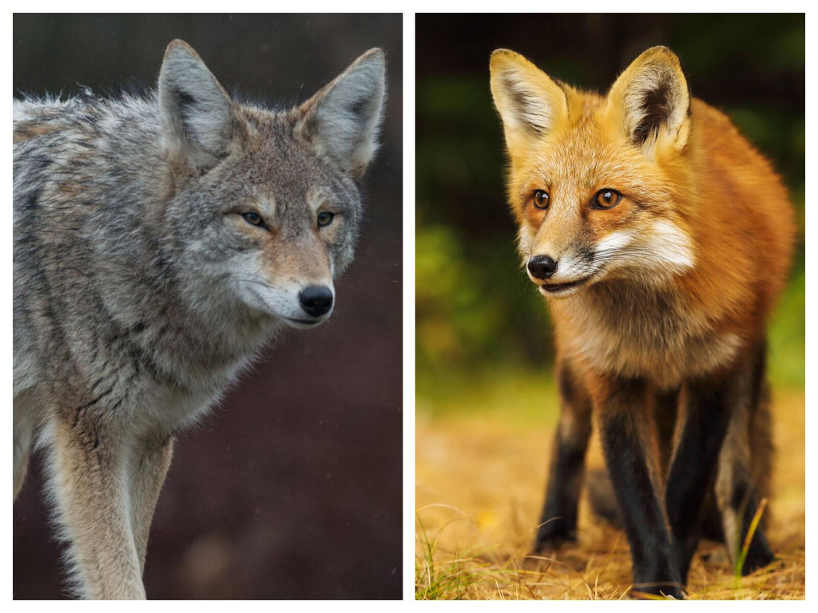

*The coyote-fox home range example “Animals” is an example of a mixed-model with perfectly balanced sample sizes. It describes the movement distances of three individuals of each of the two species across each of the four seasons.*

**Animals**

```r
Animals <- read.csv("../data/Animals.csv")
```

```r
summary <- Animals %>%
  group_by(species, season) %>%
  summarise(n = n(),
           mean_move=mean(miles),
           se_move=sd(miles)/sqrt(n()))

summary
```

```
## # A tibble: 8 × 5
## # Groups:   species [2]
##   species season     n mean_move se_move
##   <chr>   <chr>  <int>     <dbl>   <dbl>
## 1 COYOTE  fall       3      5.33   0.882
## 2 COYOTE  spring     3      7      0.577
## 3 COYOTE  summer     3      7.67   0.882
## 4 COYOTE  winter     3      3.67   0.882
## 5 FOX     fall       3      2.33   1.20
## 6 FOX     spring     3      5.33   0.333
## 7 FOX     summer     3      3      0.577
## 8 FOX     winter     3      1.33   0.882
```

```r
mixed_animals <- lmer(miles~species*season+(1|subject), data = Animals)
#note syntax for model specification:compact syntax
anova(mixed_animals) #gives us tests for fixed effects
```

```
## Type III Analysis of Variance Table with Satterthwaite's method
##                Sum Sq Mean Sq NumDF DenDF F value    Pr(>F)
## species        14.701 14.7013     1     4 11.8932 0.0260866 *
## season         47.458 15.8194     3    12 12.7978 0.0004769 ***
## species:season  7.458  2.4861     3    12  2.0112 0.1661707
## ---
## Signif. codes:  0 '***' 0.001 '**' 0.01 '*' 0.05 '.' 0.1 ' ' 1
```

```r
summary(mixed_animals)
```

```
## Linear mixed model fit by REML. t-tests use Satterthwaite's method [
## lmerModLmerTest]
## Formula: miles ~ species * season + (1 | subject)
##    Data: Animals
##
## REML criterion at convergence: 62.6
##
## Scaled residuals:
##     Min      1Q  Median      3Q     Max
## -1.4583 -0.4941  0.2338  0.6416  1.0188
##
## Random effects:
##  Groups   Name        Variance Std.Dev.
##  subject  (Intercept) 0.7639   0.874
##  Residual             1.2361   1.112
## Number of obs: 24, groups:  subject, 6
##
## Fixed effects:
##                         Estimate Std. Error      df t value Pr(>|t|)
## (Intercept)               5.3333     0.8165 11.1293   6.532 4.01e-05 ***
## speciesFOX               -3.0000     1.1547 11.1293  -2.598   0.0246 *
## seasonspring              1.6667     0.9078 12.0000   1.836   0.0912 .
## seasonsummer              2.3333     0.9078 12.0000   2.570   0.0245 *
## seasonwinter             -1.6667     0.9078 12.0000  -1.836   0.0912 .
## speciesFOX:seasonspring   1.3333     1.2838 12.0000   1.039   0.3195
## speciesFOX:seasonsummer  -1.6667     1.2838 12.0000  -1.298   0.2186
## speciesFOX:seasonwinter   0.6667     1.2838 12.0000   0.519   0.6130
## ---
## Signif. codes:  0 '***' 0.001 '**' 0.01 '*' 0.05 '.' 0.1 ' ' 1
##
## Correlation of Fixed Effects:
##               (Intr) spcFOX ssnspr ssnsmm ssnwnt spcsFOX:ssnsp spcsFOX:ssnsm
## speciesFOX    -0.707
## seasonsprng   -0.556  0.393
## seasonsummr   -0.556  0.393  0.500
## seasonwintr   -0.556  0.393  0.500  0.500
## spcsFOX:ssnsp  0.393 -0.556 -0.707 -0.354 -0.354
## spcsFOX:ssnsm  0.393 -0.556 -0.354 -0.707 -0.354  0.500
## spcsFOX:ssnw   0.393 -0.556 -0.354 -0.354 -0.707  0.500         0.500
```

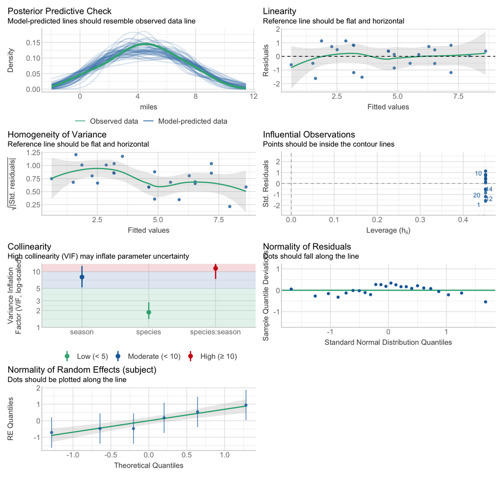

```r
performance::check_model(mixed_animals) #analogous to autoplot, but for more complex models
```

```r
#calculate model-adjusted means (e.g. estimated marginal means)
mixed_animals_emm <- emmeans(mixed_animals, "season", "species")
mixed_animals_emm
```

```
## species = COYOTE:
##  season emmean    SE   df lower.CL upper.CL
##  fall     5.33 0.816 11.1    3.539     7.13
##  spring   7.00 0.816 11.1    5.205     8.79
##  summer   7.67 0.816 11.1    5.872     9.46
##  winter   3.67 0.816 11.1    1.872     5.46
##
## species = FOX:
##  season emmean    SE   df lower.CL upper.CL
##  fall     2.33 0.816 11.1    0.539     4.13
##  spring   5.33 0.816 11.1    3.539     7.13
##  summer   3.00 0.816 11.1    1.205     4.79
##  winter   1.33 0.816 11.1   -0.461     3.13
##
## Degrees-of-freedom method: kenward-roger
## Confidence level used: 0.95
```

Lets get the summary data in one place for plotting a figure.

```r
data_emm <- as.data.frame(summary(mixed_animals_emm))
#data_emm <- as.data.frame(summary(mixed_animals_emm))[c('season', 'species', 'emmean', 'SE')] #specify columns to print
data_emm
```

```
## species = COYOTE:
##  season   emmean        SE    df  lower.CL upper.CL
##  fall   5.333333 0.8164966 11.13  3.538781 7.127886
##  spring 7.000000 0.8164966 11.13  5.205447 8.794553
##  summer 7.666667 0.8164966 11.13  5.872114 9.461219
##  winter 3.666667 0.8164966 11.13  1.872114 5.461219
##
## species = FOX:
##  season   emmean        SE    df  lower.CL upper.CL
##  fall   2.333333 0.8164966 11.13  0.538781 4.127886
##  spring 5.333333 0.8164966 11.13  3.538781 7.127886
##  summer 3.000000 0.8164966 11.13  1.205447 4.794553
##  winter 1.333333 0.8164966 11.13 -0.461219 3.127886
##
## Degrees-of-freedom method: kenward-roger
## Confidence level used: 0.95
```

```r
#model-adjusted means (emm) are identical to raw means (see above) since nothing really being adjusted in fully balanced experiment.
```

```r
#notice that SE is same value for all emmeans: this is expected

#https://www.ibm.com/support/pages/estimated-marginal-means-all-have-same-standard-error-spss#:~:text=Both%20are%20correct%2C%20because%20the,variation%20about%20that%20group's%20mean.&text=The%20model%20is%20that%20each,same%20for%20all%20the%20groups.

#https://stats.stackexchange.com/questions/444707/standard-error-in-estimated-marginal-means-are-all-the-same

#https://github.com/jamovi/jamovi/issues/660
```

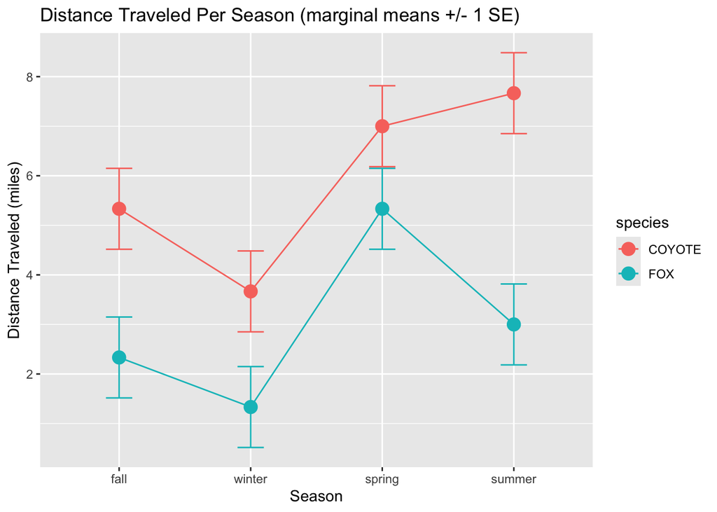

```r
#relevel factors into intuitive order
data_emm$season <- factor(data_emm$season, levels = c("fall", "winter", "spring", "summer"))

p<- ggplot(data_emm, aes(x=season, y=emmean, group=species, color=species)) +
  geom_line() +
  geom_point(size=4)+
  geom_errorbar(aes(ymin=emmean-SE, ymax=emmean+SE), width=.2)+
  labs(title="Distance Traveled Per Season (marginal means +/- 1 SE)", x="Season", y = "Distance Traveled (miles)")
p
```

```r
pairs(emmeans(mixed_animals, "species", "season"))
```

```
## season = fall:
##  contrast     estimate   SE   df t.ratio p.value
##  COYOTE - FOX     3.00 1.15 11.1   2.598  0.0246
##
## season = spring:
##  contrast     estimate   SE   df t.ratio p.value
##  COYOTE - FOX     1.67 1.15 11.1   1.443  0.1765
##
## season = summer:
##  contrast     estimate   SE   df t.ratio p.value
##  COYOTE - FOX     4.67 1.15 11.1   4.041  0.0019
##
## season = winter:
##  contrast     estimate   SE   df t.ratio p.value
##  COYOTE - FOX     2.33 1.15 11.1   2.021  0.0680
##
## Degrees-of-freedom method: kenward-roger
```

```r
pairs(emmeans(mixed_animals, "season", "species"))
```

```
## species = COYOTE:
##  contrast        estimate    SE df t.ratio p.value
##  fall - spring     -1.667 0.908 12  -1.836  0.3045
##  fall - summer     -2.333 0.908 12  -2.570  0.0983
##  fall - winter      1.667 0.908 12   1.836  0.3045
##  spring - summer   -0.667 0.908 12  -0.734  0.8814
##  spring - winter    3.333 0.908 12   3.672  0.0146
##  summer - winter    4.000 0.908 12   4.406  0.0041
##
## species = FOX:
##  contrast        estimate    SE df t.ratio p.value
##  fall - spring     -3.000 0.908 12  -3.305  0.0279
##  fall - summer     -0.667 0.908 12  -0.734  0.8814
##  fall - winter      1.000 0.908 12   1.102  0.6953
##  spring - summer    2.333 0.908 12   2.570  0.0983
##  spring - winter    4.000 0.908 12   4.406  0.0041
##  summer - winter    1.667 0.908 12   1.836  0.3045
##
## Degrees-of-freedom method: kenward-roger
## P value adjustment: tukey method for comparing a family of 4 estimates
```

```r
#pairs(mixed_animals_emm)
```

```r
emmeans(mixed_animals_emm, specs = pairwise ~ season:species)
```

```
## $emmeans
##  season species emmean    SE   df lower.CL upper.CL
##  fall   COYOTE    5.33 0.816 11.1    3.539     7.13
##  spring COYOTE    7.00 0.816 11.1    5.205     8.79
##  summer COYOTE    7.67 0.816 11.1    5.872     9.46
##  winter COYOTE    3.67 0.816 11.1    1.872     5.46
##  fall   FOX       2.33 0.816 11.1    0.539     4.13
##  spring FOX       5.33 0.816 11.1    3.539     7.13
##  summer FOX       3.00 0.816 11.1    1.205     4.79
##  winter FOX       1.33 0.816 11.1   -0.461     3.13
##
## Degrees-of-freedom method: kenward-roger
## Confidence level used: 0.95
##
## $contrasts
##  contrast                      estimate    SE   df t.ratio p.value
##  fall COYOTE - spring COYOTE     -1.667 0.908 12.0  -1.836  0.6109
##  fall COYOTE - summer COYOTE     -2.333 0.908 12.0  -2.570  0.2543
##  fall COYOTE - winter COYOTE      1.667 0.908 12.0   1.836  0.6109
##  fall COYOTE - fall FOX           3.000 1.155 11.1   2.598  0.2501
##  fall COYOTE - spring FOX         0.000 1.155 11.1   0.000  1.0000
##  fall COYOTE - summer FOX         2.333 1.155 11.1   2.021  0.5096
##  fall COYOTE - winter FOX         4.000 1.155 11.1   3.464  0.0690
##  spring COYOTE - summer COYOTE   -0.667 0.908 12.0  -0.734  0.9938
##  spring COYOTE - winter COYOTE    3.333 0.908 12.0   3.672  0.0459
##  spring COYOTE - fall FOX         4.667 1.155 11.1   4.041  0.0279
##  spring COYOTE - spring FOX       1.667 1.155 11.1   1.443  0.8207
##  spring COYOTE - summer FOX       4.000 1.155 11.1   3.464  0.0690
##  spring COYOTE - winter FOX       5.667 1.155 11.1   4.907  0.0073
##  summer COYOTE - winter COYOTE    4.000 0.908 12.0   4.406  0.0137
##  summer COYOTE - fall FOX         5.333 1.155 11.1   4.619  0.0113
##  summer COYOTE - spring FOX       2.333 1.155 11.1   2.021  0.5096
##  summer COYOTE - summer FOX       4.667 1.155 11.1   4.041  0.0279
##  summer COYOTE - winter FOX       6.333 1.155 11.1   5.485  0.0031
##  winter COYOTE - fall FOX         1.333 1.155 11.1   1.155  0.9297
##  winter COYOTE - spring FOX      -1.667 1.155 11.1  -1.443  0.8207
##  winter COYOTE - summer FOX       0.667 1.155 11.1   0.577  0.9985
##  winter COYOTE - winter FOX       2.333 1.155 11.1   2.021  0.5096
##  fall FOX - spring FOX           -3.000 0.908 12.0  -3.305  0.0833
##  fall FOX - summer FOX           -0.667 0.908 12.0  -0.734  0.9938
##  fall FOX - winter FOX            1.000 0.908 12.0   1.102  0.9445
##  spring FOX - summer FOX          2.333 0.908 12.0   2.570  0.2543
##  spring FOX - winter FOX          4.000 0.908 12.0   4.406  0.0137
##  summer FOX - winter FOX          1.667 0.908 12.0   1.836  0.6109
##
## Degrees-of-freedom method: kenward-roger
## P value adjustment: tukey method for comparing a family of 8 estimates
```

```r
#probably no a priori reason to use this table, but here it is.
```